# Exploratory Data Analysis

```
## # A tibble: 5 × 15
##   AUCTION_ID         TIMESTAMP DATE_UTC PUBLISHER_ID DEVICE_TYPE DEVICE_GEO_CITY
##   <chr>              <chr>     <chr>    <chr>              <int> <chr>
## 1 0000060c-b8a9-414… 2025-10-… 2025-10… LteIcOiSsaE5           4 Salem
## 2 0000060c-b8a9-414… 2025-10-… 2025-10… LteIcOiSsaE5           4 Salem
## 3 0000060c-b8a9-414… 2025-10-… 2025-10… LteIcOiSsaE5           4 Salem
## 4 0000060c-b8a9-414… 2025-10-… 2025-10… LteIcOiSsaE5           4 Salem
## 5 0000060c-b8a9-414… 2025-10-… 2025-10… LteIcOiSsaE5           4 Salem
## # ℹ 9 more variables: DEVICE_GEO_ZIP <chr>, PRICE <chr>, REQUESTED_SIZES <chr>,
## #   SIZE <chr>, RESPONSE_TIME <chr>, BID_WON <chr>, DEVICE_GEO_LAT <dbl>,
## #   DEVICE_GEO_LONG <dbl>, DEVICE_GEO_REGION <chr>
```

```
## # A tibble: 5 × 15
##   AUCTION_ID         TIMESTAMP DATE_UTC PUBLISHER_ID DEVICE_TYPE DEVICE_GEO_CITY
##   <chr>              <chr>     <chr>    <chr>              <int> <chr>
## 1 0000060c-b8a9-414… 2025-10-… 2025-10… LteIcOiSsaE5           4 Salem
## 2 0000060c-b8a9-414… 2025-10-… 2025-10… LteIcOiSsaE5           4 Salem
## 3 0000060c-b8a9-414… 2025-10-… 2025-10… LteIcOiSsaE5           4 Salem
## 4 0000060c-b8a9-414… 2025-10-… 2025-10… LteIcOiSsaE5           4 Salem
## 5 0000060c-b8a9-414… 2025-10-… 2025-10… LteIcOiSsaE5           4 Salem
## # ℹ 9 more variables: DEVICE_GEO_ZIP <chr>, PRICE <chr>, REQUESTED_SIZES <chr>,
## #   SIZE <chr>, RESPONSE_TIME <chr>, BID_WON <chr>, DEVICE_GEO_LAT <dbl>,
## #   DEVICE_GEO_LONG <dbl>, DEVICE_GEO_REGION <chr>
```

# Univariate Analysis

## Numerical Variables

Information Gain Scores

| attributes | importance |
| --- | --- |
| REQUESTED_SIZES | 8.7732790 |
| BID_WON | 8.7732790 |
| AUCTION_ID | 7.2821643 |
| TIMESTAMP | 5.8811804 |
| DEVICE_GEO_CITY | 0.9168208 |
| PUBLISHER_ID | 0.7873141 |
| DEVICE_TYPE | 0.5318504 |
| SIZE | 0.5197298 |
| DATE_UTC | 0.2506063 |
| DEVICE_GEO_ZIP | 0.0000000 |
| RESPONSE_TIME | 0.0000000 |
| DEVICE_GEO_LAT | 0.0000000 |
| DEVICE_GEO_LONG | 0.0000000 |
| DEVICE_GEO_REGION | 0.0000000 |

### Price

The histogram of bid prices is heavily peaked on the left, indicating that most bids are low in value. The summary statistics reveal several extreme outliers that create a right-skewed distribution, with prices reaching up to $141.25. The boxplot highlights a median bid price of approximately $0.20, with an interquartile range from $0.07 to $0.57, showing that the vast majority of bids are below $1.

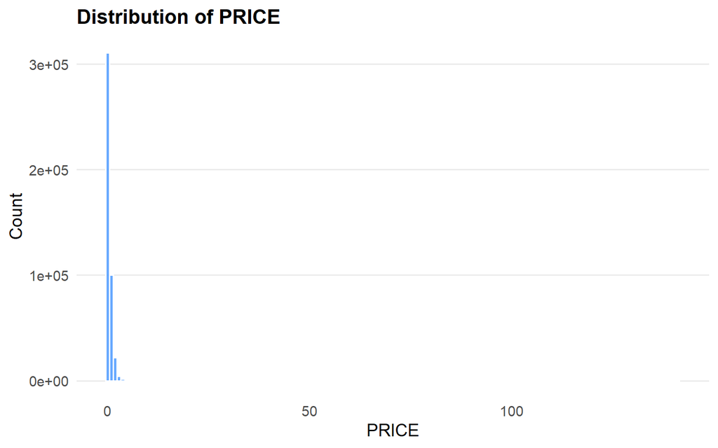

Summary Statistics for PRICE

| Min | 1st Q | Median | Mean | 3rd Q | Max | NA count |
| --- | --- | --- | --- | --- | --- | --- |
| 7.1e-05 | 0.07 | 0.196 | 0.474 | 0.57 | 141.25 | 0 |

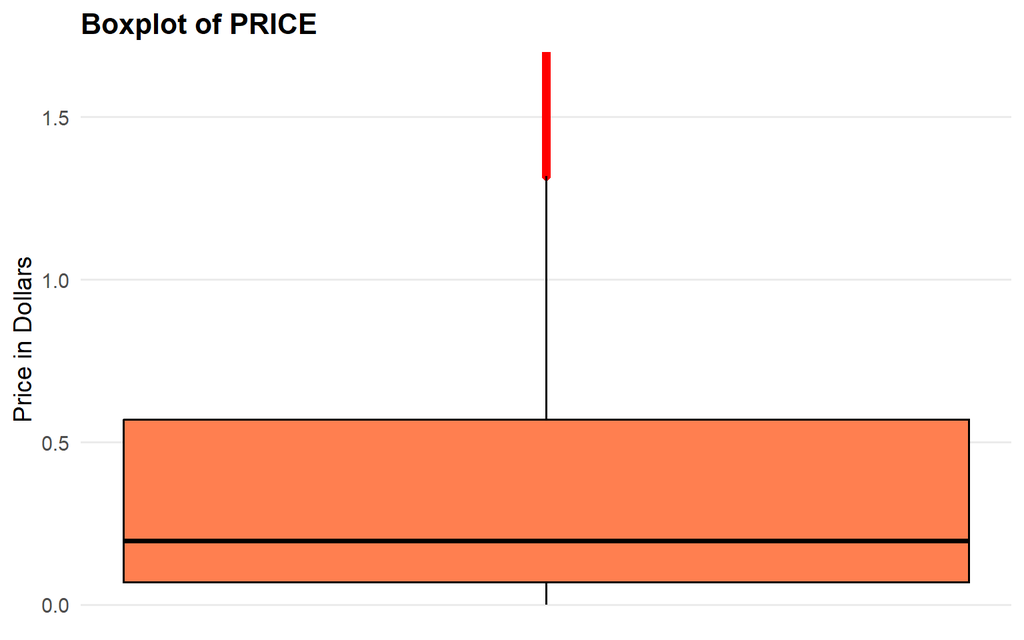

### Response Time

The histogram of the *Response Time* variable exhibits a right-skewed distribution, with the majority of observations falling between 50 and 400 milliseconds. The mean response time is 201 milliseconds. The boxplot shows a median of 164 milliseconds and an interquartile range of 110 to 257 milliseconds. While the boxplot truncates numerous outliers, these higher values are evident in the histogram. Overall, the system typically responds quickly, with a smaller subset of observations exhibiting longer response times.

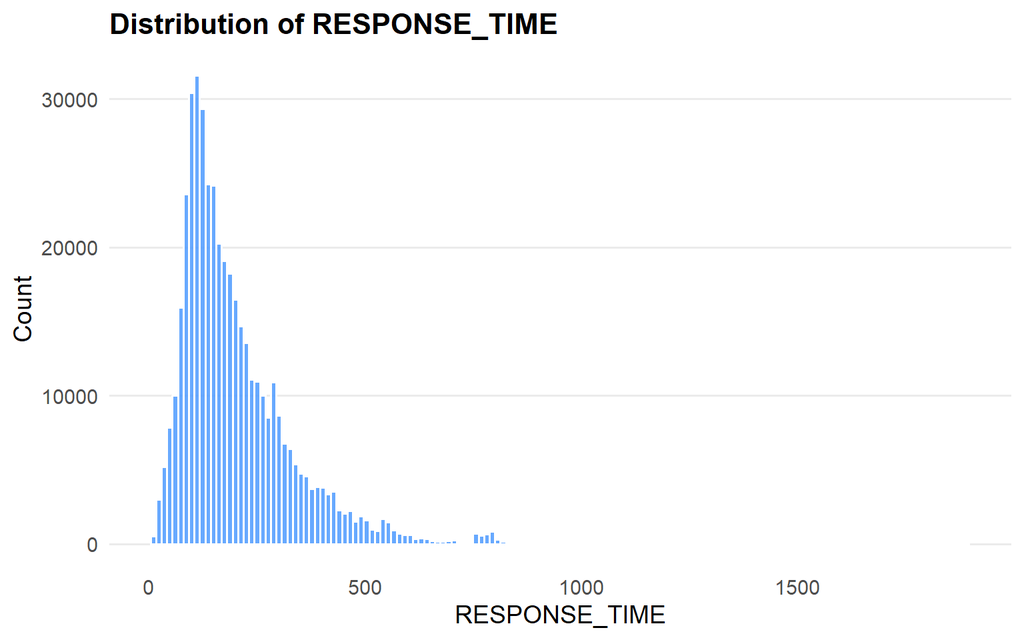

Summary Statistics for Response Time

| Min | 1st Q | Median | Mean | 3rd Q | Max | NA count |
| --- | --- | --- | --- | --- | --- | --- |
| 10 | 110 | 164 | 201.536 | 257 | 1893 | 0 |

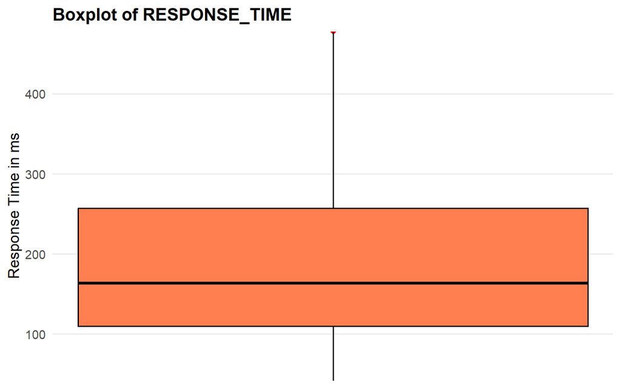

### Device Geo Latitude

The majority of latitude values fall between 45 and 46 degrees, with the minimum observed value being 42 degrees. The distribution is slightly left-skewed, peaking around 45.5 degrees. The boxplot shows a median latitude of 45.514, with a narrow interquartile range from 45.3 to 45.525. These findings are consistent with the fact that the bid data were collected exclusively within Oregon.

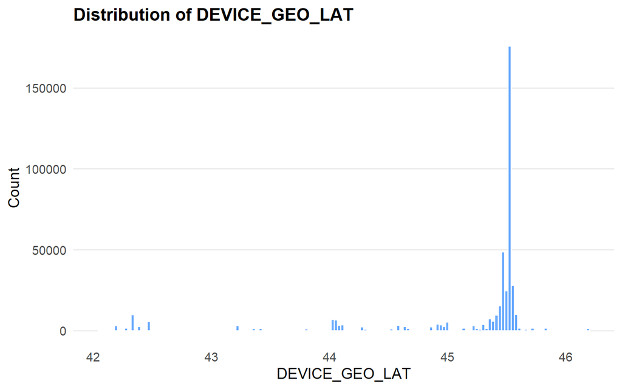

Summary Statistics for Latitude

| Min | 1st Q | Median | Mean | 3rd Q | Max | NA count |
| --- | --- | --- | --- | --- | --- | --- |
| 42.055 | 45.357 | 45.514 | 45.143 | 45.525 | 46.1879 | 0 |

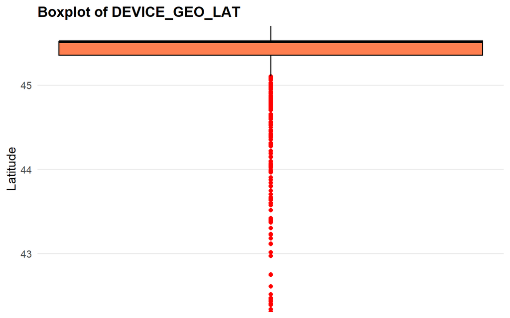

## Categorical Variables

### Device Type

Within the *Device Type* variable, two categories (*Personal Computers* and *Tablets*) dominate, together comprising 93.5% of the dataset. These device types therefore exert a strong influence on the overall distribution. The *Connected Device* category is the least common, representing only 0.07% of observations.

| DEVICE_TYPE | Count | Percent |
| --- | --- | --- |
| Personal Computer | 229203 | 51.98 |
| Tablet | 183076 | 41.52 |
| Connected TV | 24639 | 5.59 |
| Mobile/Tablet | 3697 | 0.84 |
| Connected Device | 322 | 0.07 |

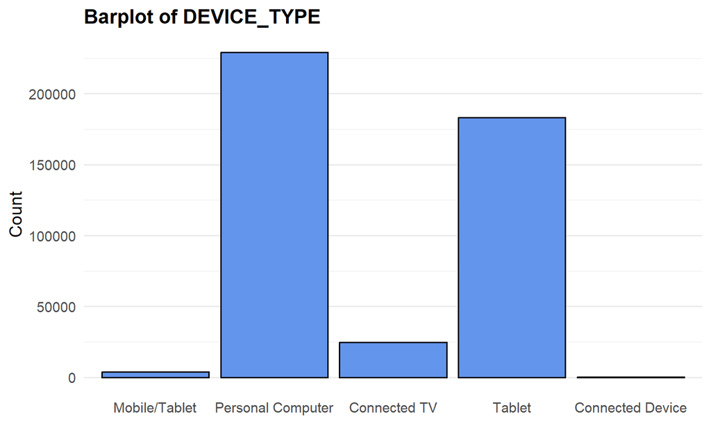

### Device Geo City

Portland is the most frequently represented city in the dataset, accounting for nearly 60% of all observations. The next most common cities (Salem, Beaverton, and Hillsboro) each contribute roughly 3% of the data. Given Portland’s population density, it has a disproportionately large influence on the bid data compared to the other cities included.

| DEVICE_GEO_CITY | Count | Percent |
| --- | --- | --- |
| Portland | 263884 | 59.85 |
| Salem | 14373 | 3.26 |
| Beaverton | 13998 | 3.17 |
| Hillsboro | 13603 | 3.09 |
| Medford | 11618 | 2.63 |
| Eugene | 9969 | 2.26 |
| Gresham | 9952 | 2.26 |
| Other | 103540 | 23.40 |

### Device Geo Zip

| DEVICE_GEO_ZIP | Count | Percent |
| --- | --- | --- |
| 97232 | 44792 | 10.16 |
| 97233 | 30832 | 6.99 |
| 97252 | 30014 | 6.81 |
| 97216 | 24449 | 5.54 |
| 97206 | 24392 | 5.53 |
| 97214 | 16353 | 3.71 |
| 97202 | 12248 | 2.78 |
| Other | 257857 | 58.38 |

### Size

The most common ad sizes in the auction are *320x50* and *300x250*, comprising 60% and 30% of all bids, respectively, for a combined total of 399,140 observations. The next most frequent size, *300x50*, appears in 22,547 observations, representing approximately 5% of the dataset. A large number of other ad sizes occur very infrequently, each appearing fewer than 10 times.

| SIZE | Count | Percent |
| --- | --- | --- |
| 320x50 | 267589 | 60.69 |
| 300x250 | 131551 | 29.83 |
| 300x50 | 22547 | 5.11 |
| 300x600 | 7282 | 1.65 |
| 728x90 | 6968 | 1.58 |
| 970x250 | 2500 | 0.57 |
| 300x251 | 320 | 0.07 |
| Other | 2180 | 0.48 |

### Bid Won

The barplot of *BID_WON* reveals that losing bids substantially outnumber winning bids. Although the primary focus of the analysis is on the relationship between bid outcomes and price, it is notable that losses occur nearly three times as often as wins.

| BID_WON | Count | Percent |
| --- | --- | --- |
| FALSE | 320429 | 72.67 |
| TRUE | 120508 | 27.33 |

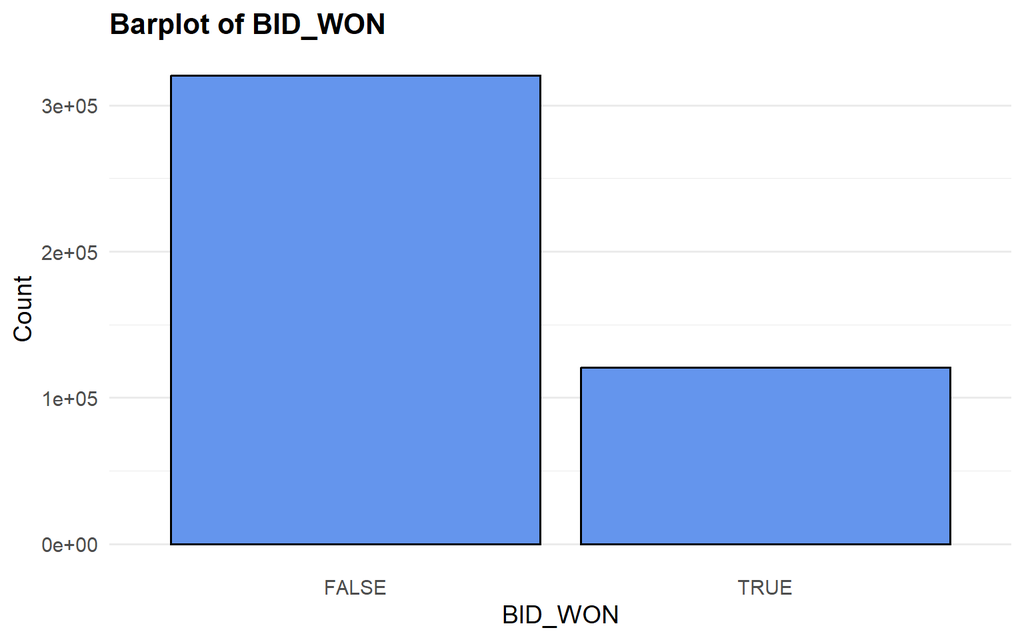

### Device Geo Region

As noted previously, all data points are located within the state of Oregon, restricting the analysis to this specific geographic region.

| DEVICE_GEO_REGION | Count | Percent |
| --- | --- | --- |
| OR | 440937 | 100 |

# Bivariate Analysis

## Numerical vs Numerical

### Price and Response Time

Several extreme values in the price variable deviate from the overall distribution. There appears to be a potential relationship where longer response times are associated with lower bid prices, suggesting that slower bidders may enter lower initial bids and subsequently lose to faster competitors. Additionally, some points are clearly separated from the main distribution, likely representing bidders who either submitted higher-priced bids initially or were able to quickly adjust and rebid at a higher price within the same auction.

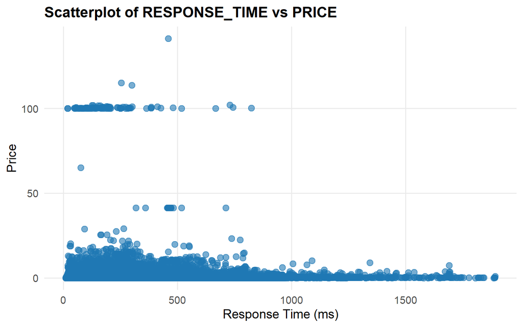

### Price and Latitude

The scatterplot of latitude versus price suggests a slight increase in bid prices around the 45.5-degree latitude mark. The higher concentration of points in this area are likely to be related to greater population density. Additionally, we observe a pattern similar to the Price versus Response Time graph, with some bids significantly higher than the main distribution. These points may represent a “second round” of bidding, where initial lower bids were rejected and subsequently raised.

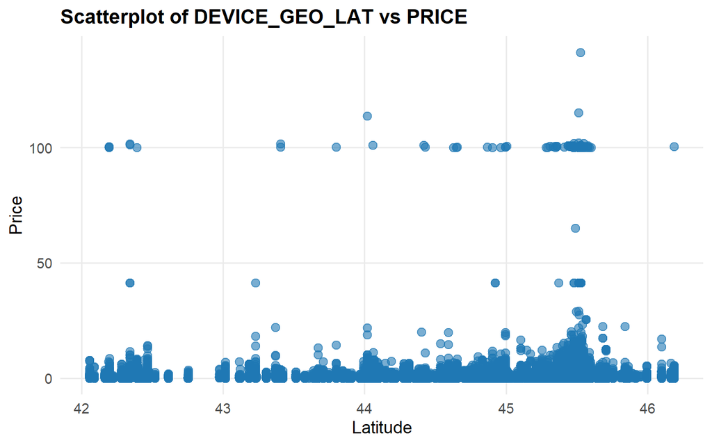

### Price and Longitude

Similar to the latitude plot, a large cluster of points is observed around -122.5 degrees longitude, likely reflecting areas of higher population density. Additionally, the pattern of higher-priced bids above the main distribution persists, suggesting a secondary set of elevated bids originating from these locations.

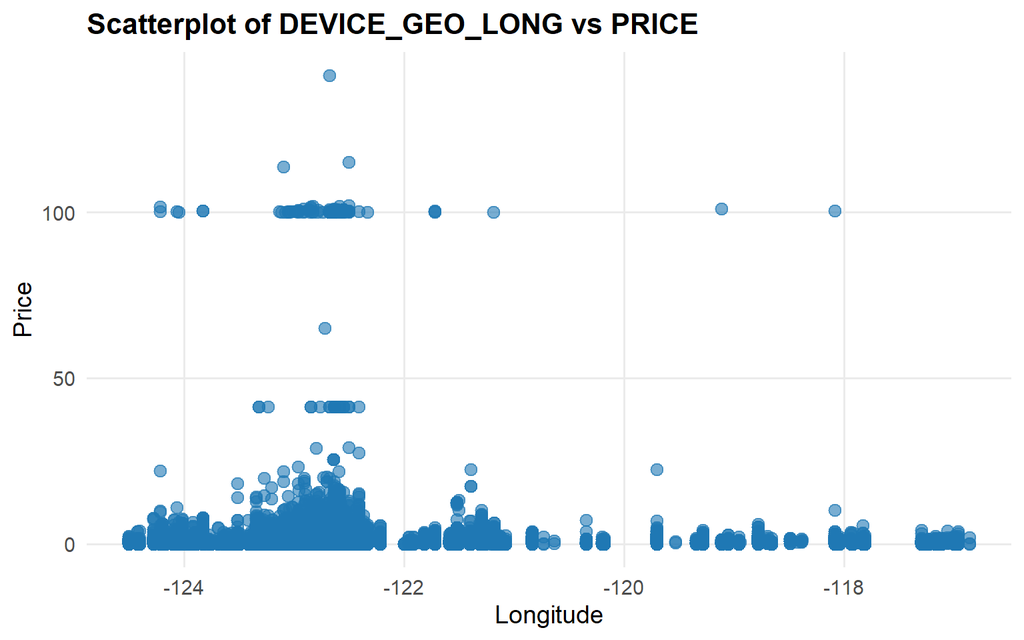

### Latitude and Response Time

The scatterplot of Latitude versus Response Time exhibits a generally consistent distribution of points across different latitudes, with the exception of a spike on the right side. There is a notable concentration of points around 45.5 degrees, and several other locations show outliers with unusually long response times.

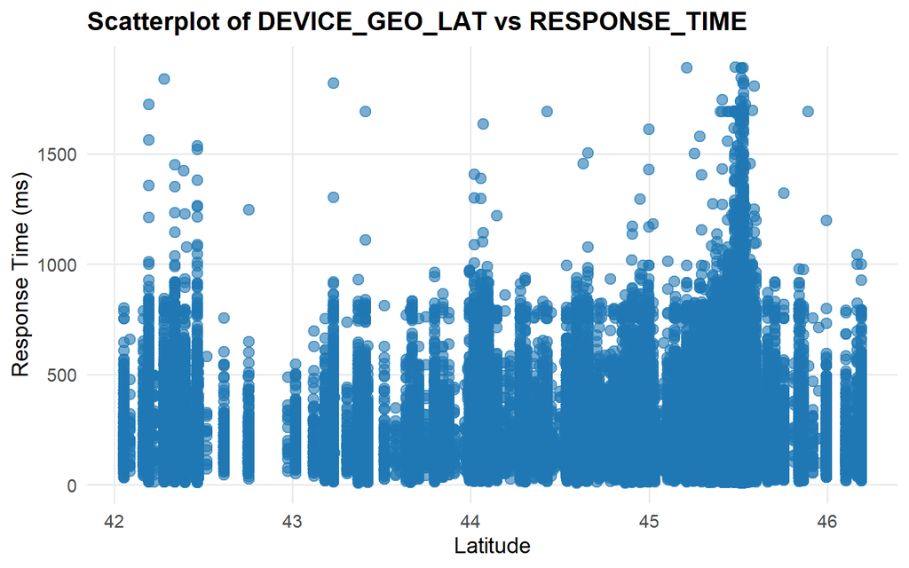

### Longitude and Response Time

The scatterplot shows a spike of higher response time values around longitude -123, with noticeably fewer points toward the right side of the plot. This may indicate that a specific location experiences slower response times, although it could also reflect lower sample density in that area. Additionally, there are no substantial outliers beyond longitude -121, suggesting a faster average response in these locations compared to the majority of the data.

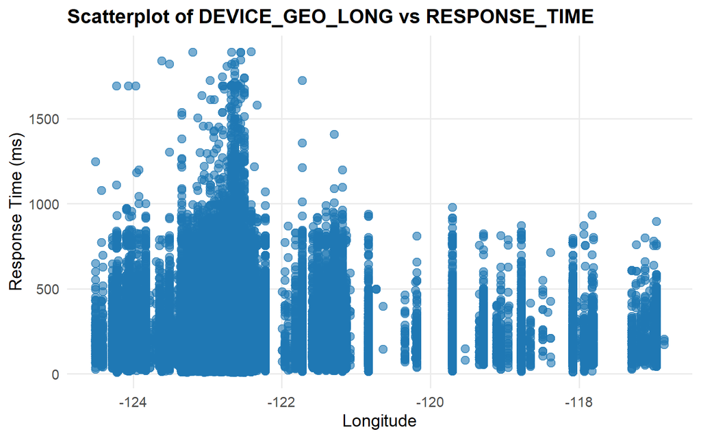

## Numerical vs Categorical

### Price and Bid Won

A t-test, yielding an extremely significant p-value (2.2e-16), confirms a statistically significant difference in mean prices between won and lost bids. The accompanying boxplot illustrates the distribution of bid prices by outcome, clearly highlighting the separation between the two groups. For readability, the plot has been zoomed in to emphasize differences in median values and overall distribution. Notably, the median price of winning bids is substantially higher than that of losing bids, with a wider interquartile range, and the IQRs of the two groups do not overlap.

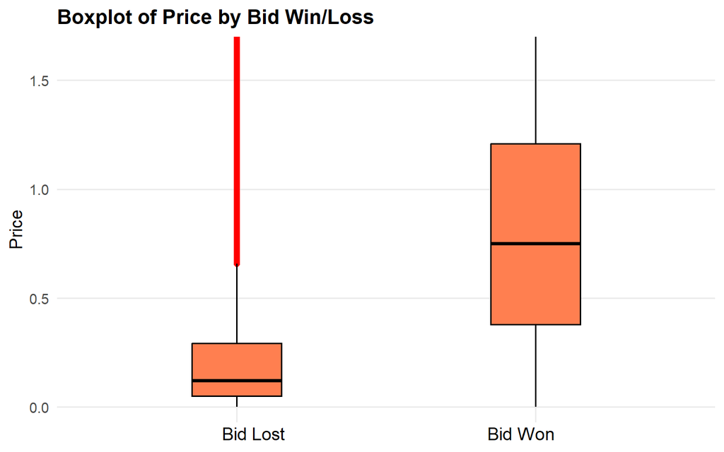

### Price and Device Type

The boxplot of Device Type versus Price shows that the *Tablet*, *Personal Computer*, and *Mobile/Tablet* categories have comparable median prices. However, the interquartile range for *Tablet* is notably narrower, indicating lower variability within this group. In contrast, the Connected Device category exhibits both the highest median price and the widest IQR, reflecting substantially greater variability. This pattern may point to underlying factors contributing to the broader distribution of prices within this device type.

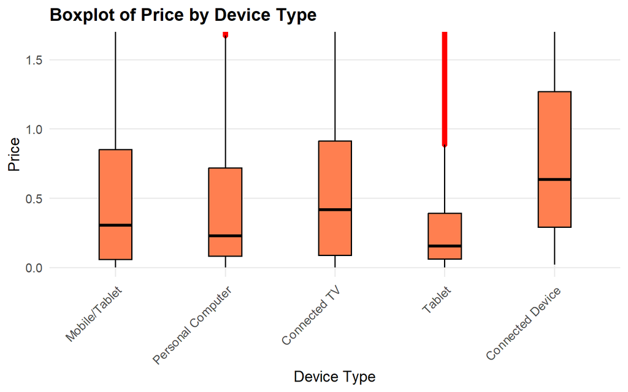

### Median Bid Price by City

The visualization below illustrates the geographic distribution of median bid prices across Oregon. Cooler colors correspond to lower CMP values, while warmer colors (orange and yellow) indicate higher CMP levels. The largest circles show areas with the highest concentration of bids, most notably in northern Oregon around Portland. Despite the high bid volume in this region, the median CPM remains relatively low, typically between 0.2 and 0.3. Surrounding areas and parts of the Oregon coast exhibit noticeably higher median CPM values.

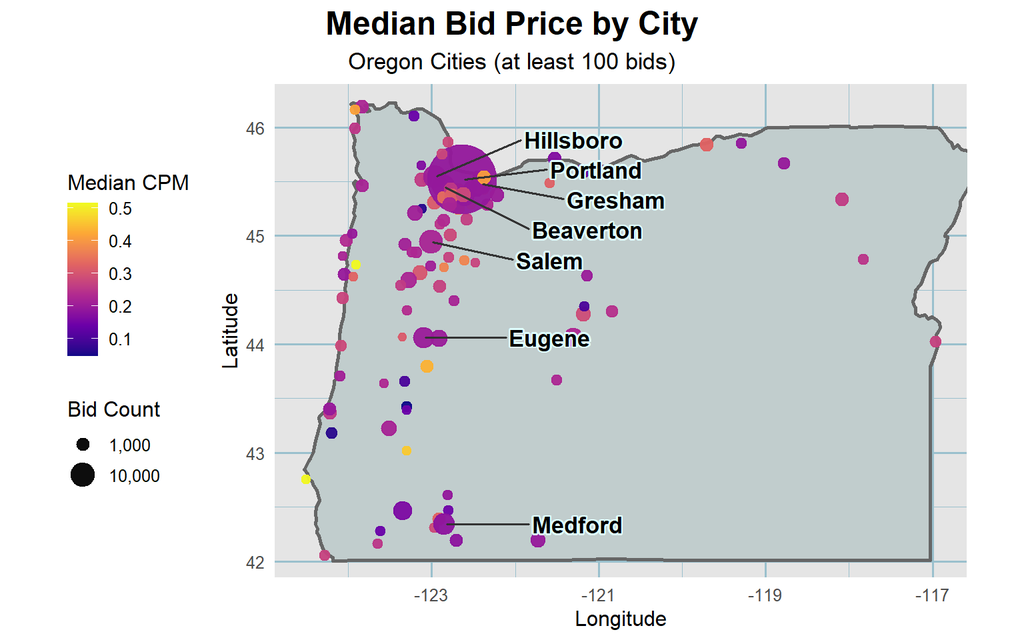

### Response Time by City

This map shows median response times across Oregon cities. As in the previous map, cooler colors indicate lower response times, while warmer colors represent higher values. Portland, the most prominent city, appears on the cooler end of the spectrum, indicating a median response time lower than that of several outlying cities. Some nearby cities exhibit even lower response times, whereas a few locations in southern Oregon show comparatively higher values.

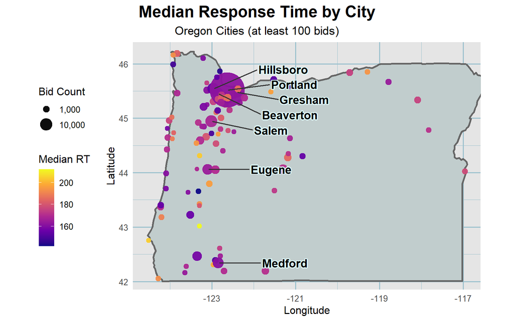

### Device Type and Response Time

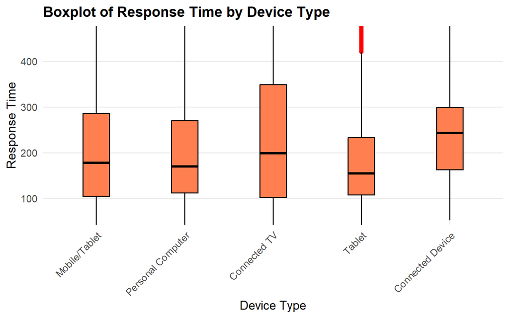

### Device Type and Timestamp

[figure not shown]

## Categorical vs Categorical

### Device Type by City

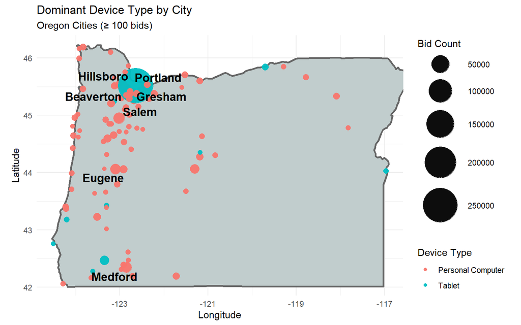

# Key Findings

## Conclusion

The analysis indicates that most bids are low in price, with a few extreme outliers producing a right-skewed distribution. Winning bids are consistently higher than losing bids, confirming that win rate is strongly associated with price. Device type and geographic location both influence bid price and response time, with Personal Computers and Tablets dominating the dataset. Although response time shows only minor variation across devices and regions, some outliers could affect bidding outcomes. High population areas, such as Portland, account for the majority of bids, yet median prices in these regions remain moderate.

## Limitations

The analysis is limited by the dataset being restricted to Oregon, which may reduce the generalizability of findings to other regions. The high concentration of observations from Portland could skew overall results. Outliers in both price and response time introduce bias to mean-based measures, necessitating the use of medians for more robust insights. Additionally, two device type categories have some overlap, which may prevent a full understanding of the nuances in hardware or network performance.

## Future Analysis

Future analyses could explore the causal factors influencing bid success, including device performance and response times. Expanding the dataset to cover a longer time period would allow for the investigation of temporal patterns in bidding behavior. Additionally, examining interaction effects between variables such as device type, geographic location, time of day, and bid price could provide deeper insights into the dynamics driving successful bids.